# What emotions do some well-known philosophers express in their masterpieces?

Bohao Ma

9/27/2021

When it comes to philosophy, we tend to focus on philosophers’ thoughts and beliefs about some fundamental questions, such as those about value, mind, and existence. However, we rarely pay attention to the emotions expressed in some masterpieces of philosophy. In this report, therefore, I aim at answering the following question: what emotions do some well-known philosophers express in their masterpieces? Are they more emotionally charged or neutral in their texts?

## 0. Dataset and Data Processing

The dataset used for analysis is the dataset compiled for [the Philosophy Data Project](http://www.philosophydata.com/). This dataset contains 59 masterpieces, written by 36 well-known philosophers from 13 schools of philosophy. This dataset has been extensively cleaned by its creator and it contains no missing values or abnormal inputs. So I perform no extra data cleaning on it.

As for sentiment analysis, I rely on [the NRC Emotion Lexicon](https://saifmohammad.com/WebPages/NRC-Emotion-Lexicon.htm). It is “a list of English words and their associations with eight basic emotions (anger, fear, anticipation, trust, surprise, sadness, joy, and disgust) and two sentiments (negative and positive).” I choose sentences as the unit for analysis since they are the natural units for organizing thoughts and expressing emotions. An emotion score, which represents the “strength” of a certain type of emotion, for each of the eight basic emotions, is assigned to each sentence in the dataset with the *get_nrc_sentiment* function in the *syuzhet* package. For simplicity, I then assign the emotion with the highest emotion score as the (top) emotion for that sentence. (If multiple emotions in a sentence achieve the highest emotion score, one of them is chosen randomly as the emotion for that sentence.) Lastly, I classify sentences with zero sentiment score across all eight emotions as emotionally neutral.

## 1. Overall, what types of emotion are expressed in philosophy texts?

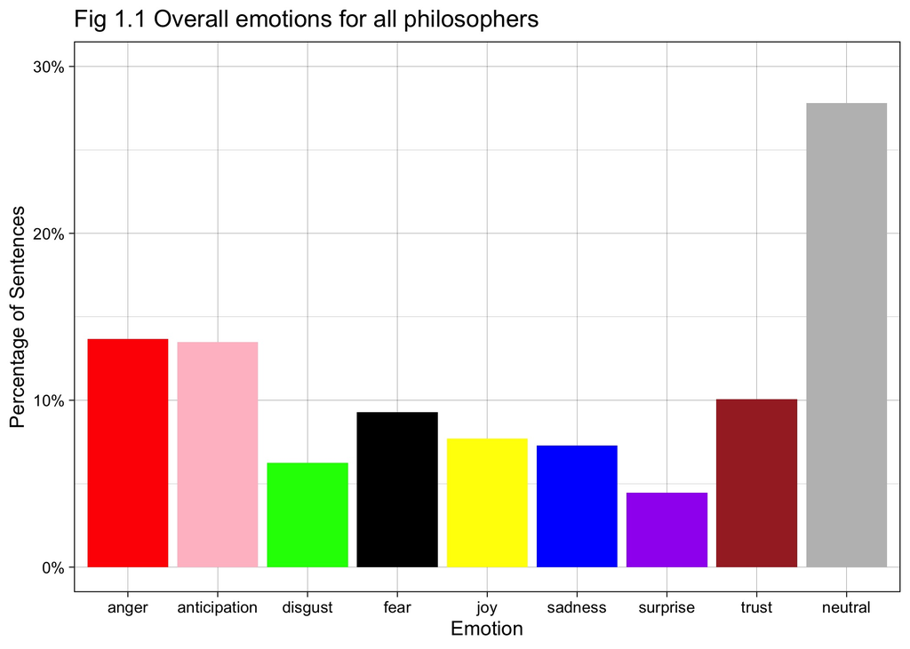

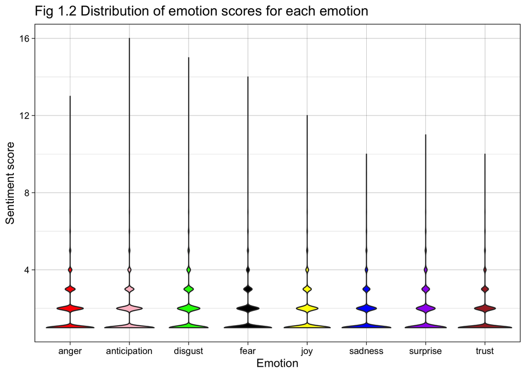

## 2. Are there any differences between philosopher in terms of expressing emotions in their texts?

Despite the overall emotional neutrality, there are some major differences between the philosophers in terms of emotional expression. As shown in the two tables below, for example, only 10.55% of Wollstonecraft’s sentences are emotionally neutral whereas 46.01% of Wittgenstein’s sentences are neutral. Such huge differences can be explained by the different writing styles of the philosophers as well as the emotional states of the philosophers when they were writing the texts.

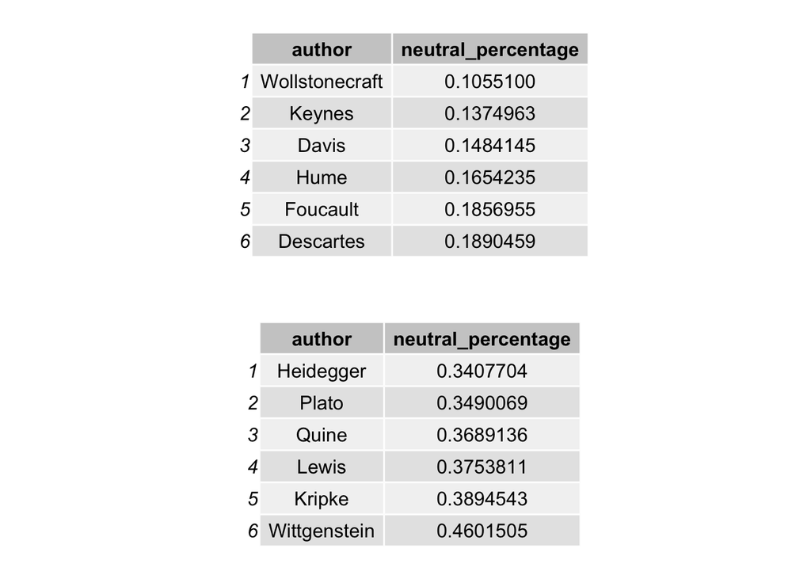

## 3. Do philosophers from different schools of philosophy tend to express different emotions in their masterpieces?

Philosophers from different schools of philosophy can have distinct or sometimes contradicting values and beliefs. So an interesting question is whether such differences influence the types of emotions expressed in the texts from various schools of philosophy.

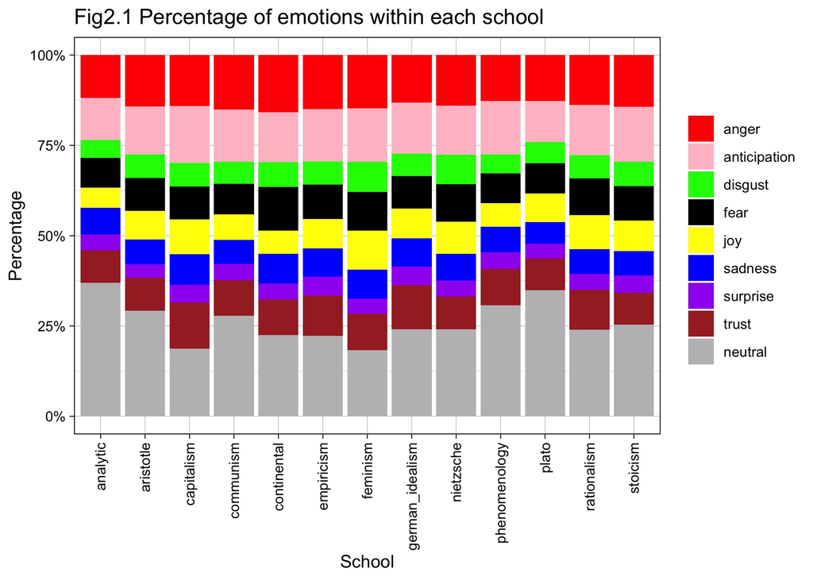

## 4. Conclusion

- Although there are some highly emotionally charged sentences, the majority (70%) of sentences in the philosophical texts are emotional neutral or close to being neutral.
- Trust, anticipation, and anger are the major types of emotions expressed in the philosophical texts.
- There are some major differences between the philosophers in terms of emotional expression in their texts.
- On average philosophers from different schools of philosophy tend to express similar types of emotion even when they are trying to elaborate very different thoughts or ideas.

## 5. Caveats

There are some important caveats to be kept in mind about this report.

- For simplicity, I classify the emotion with the highest emotion score as the (top) emotion for that sentence. This methodology ignores the subtlety of mixed emotions in a sentence.
- Although the dataset is tidy, the accuracy of the philosophical texts cannot be guaranteed or verified by me. For example, without checking the original texts carefully, I cannot tell whether there is a typo in a certain sentence.
- The philosophers and texts included in the dataset might not be a representative sample. They are a very small subset of the population of all philosophers and all texts in philosophy. Moreover, it only includes philosophers in the West. Hence, strictly speaking, the conclusions of this report should only apply to the philosophers and texts covered in the dataset.
- Some of the texts are not written in English. (e.g. Plato and Aristotle certainly did not know English.) So the sentiment analysis based on English vocabulary depends highly on the quality/version of translation.

This notebook was prepared with the following environmental settings.

```r
print(R.version)
```

```
##                _
## platform       x86_64-apple-darwin17.0
## arch           x86_64
## os             darwin17.0
## system         x86_64, darwin17.0
## status
## major          4
## minor          0.3
## year           2020
## month          10
## day            10
## svn rev        79318
## language       R
## version.string R version 4.0.3 (2020-10-10)
## nickname       Bunny-Wunnies Freak Out
```